# Risk Factor Analysis

## Outcome Variable

**Outcome Variable:** ever_stunted

## Predictor Variables

**Intervention Variable:** cleanck

**Adjustment Set:**

unadjusted

## Stratifying Variables

The analysis was stratified on these variable(s):

- agecat
- studyid
- country

## Data Summary

| agecat | studyid | country | cleanck | ever_stunted | n_cell | n |
| --- | --- | --- | --- | --- | --- | --- |
| 0-6 months | ki0047075b-MAL-ED | PERU | 0 | 0 | 1 | 2 |
| 0-6 months | ki0047075b-MAL-ED | PERU | 1 | 0 | 1 | 2 |
| 0-6 months | ki0047075b-MAL-ED | SOUTH AFRICA | 0 | 0 | 1 | 3 |
| 0-6 months | ki0047075b-MAL-ED | SOUTH AFRICA | 0 | 1 | 0 | 3 |
| 0-6 months | ki0047075b-MAL-ED | SOUTH AFRICA | 1 | 0 | 0 | 3 |
| 0-6 months | ki0047075b-MAL-ED | SOUTH AFRICA | 1 | 1 | 2 | 3 |
| 0-6 months | ki1000108-CMC-V-BCS-2002 | INDIA | 0 | 0 | 151 | 368 |
| 0-6 months | ki1000108-CMC-V-BCS-2002 | INDIA | 0 | 1 | 55 | 368 |
| 0-6 months | ki1000108-CMC-V-BCS-2002 | INDIA | 1 | 0 | 141 | 368 |
| 0-6 months | ki1000108-CMC-V-BCS-2002 | INDIA | 1 | 1 | 21 | 368 |
| 0-6 months | ki1000108-IRC | INDIA | 0 | 0 | 144 | 400 |
| 0-6 months | ki1000108-IRC | INDIA | 0 | 1 | 25 | 400 |
| 0-6 months | ki1000108-IRC | INDIA | 1 | 0 | 208 | 400 |
| 0-6 months | ki1000108-IRC | INDIA | 1 | 1 | 23 | 400 |
| 0-6 months | ki1017093b-PROVIDE | BANGLADESH | 0 | 0 | 113 | 700 |
| 0-6 months | ki1017093b-PROVIDE | BANGLADESH | 0 | 1 | 16 | 700 |
| 0-6 months | ki1017093b-PROVIDE | BANGLADESH | 1 | 0 | 521 | 700 |
| 0-6 months | ki1017093b-PROVIDE | BANGLADESH | 1 | 1 | 50 | 700 |
| 0-6 months | ki1017093c-NIH-Crypto | BANGLADESH | 0 | 0 | 184 | 577 |
| 0-6 months | ki1017093c-NIH-Crypto | BANGLADESH | 0 | 1 | 33 | 577 |
| 0-6 months | ki1017093c-NIH-Crypto | BANGLADESH | 1 | 0 | 314 | 577 |
| 0-6 months | ki1017093c-NIH-Crypto | BANGLADESH | 1 | 1 | 46 | 577 |
| 0-6 months | ki1113344-GMS-Nepal | NEPAL | 0 | 0 | 468 | 537 |
| 0-6 months | ki1113344-GMS-Nepal | NEPAL | 0 | 1 | 60 | 537 |
| 0-6 months | ki1113344-GMS-Nepal | NEPAL | 1 | 0 | 9 | 537 |
| 0-6 months | ki1113344-GMS-Nepal | NEPAL | 1 | 1 | 0 | 537 |
| 6-24 months | ki0047075b-MAL-ED | SOUTH AFRICA | 1 | 0 | 1 | 1 |
| 6-24 months | ki1000108-CMC-V-BCS-2002 | INDIA | 0 | 0 | 39 | 288 |
| 6-24 months | ki1000108-CMC-V-BCS-2002 | INDIA | 0 | 1 | 111 | 288 |
| 6-24 months | ki1000108-CMC-V-BCS-2002 | INDIA | 1 | 0 | 58 | 288 |
| 6-24 months | ki1000108-CMC-V-BCS-2002 | INDIA | 1 | 1 | 80 | 288 |
| 6-24 months | ki1000108-IRC | INDIA | 0 | 0 | 98 | 331 |
| 6-24 months | ki1000108-IRC | INDIA | 0 | 1 | 38 | 331 |
| 6-24 months | ki1000108-IRC | INDIA | 1 | 0 | 152 | 331 |
| 6-24 months | ki1000108-IRC | INDIA | 1 | 1 | 43 | 331 |
| 6-24 months | ki1017093b-PROVIDE | BANGLADESH | 0 | 0 | 39 | 497 |
| 6-24 months | ki1017093b-PROVIDE | BANGLADESH | 0 | 1 | 27 | 497 |
| 6-24 months | ki1017093b-PROVIDE | BANGLADESH | 1 | 0 | 339 | 497 |
| 6-24 months | ki1017093b-PROVIDE | BANGLADESH | 1 | 1 | 92 | 497 |
| 6-24 months | ki1017093c-NIH-Crypto | BANGLADESH | 0 | 0 | 159 | 483 |
| 6-24 months | ki1017093c-NIH-Crypto | BANGLADESH | 0 | 1 | 30 | 483 |
| 6-24 months | ki1017093c-NIH-Crypto | BANGLADESH | 1 | 0 | 241 | 483 |
| 6-24 months | ki1017093c-NIH-Crypto | BANGLADESH | 1 | 1 | 53 | 483 |
| 6-24 months | ki1113344-GMS-Nepal | NEPAL | 0 | 0 | 227 | 429 |
| 6-24 months | ki1113344-GMS-Nepal | NEPAL | 0 | 1 | 194 | 429 |
| 6-24 months | ki1113344-GMS-Nepal | NEPAL | 1 | 0 | 7 | 429 |
| 6-24 months | ki1113344-GMS-Nepal | NEPAL | 1 | 1 | 1 | 429 |
| 0-24 months | ki0047075b-MAL-ED | PERU | 0 | 0 | 1 | 2 |
| 0-24 months | ki0047075b-MAL-ED | PERU | 1 | 0 | 1 | 2 |
| 0-24 months | ki0047075b-MAL-ED | SOUTH AFRICA | 0 | 0 | 1 | 3 |
| 0-24 months | ki0047075b-MAL-ED | SOUTH AFRICA | 0 | 1 | 0 | 3 |
| 0-24 months | ki0047075b-MAL-ED | SOUTH AFRICA | 1 | 0 | 0 | 3 |
| 0-24 months | ki0047075b-MAL-ED | SOUTH AFRICA | 1 | 1 | 2 | 3 |
| 0-24 months | ki1000108-CMC-V-BCS-2002 | INDIA | 0 | 0 | 29 | 373 |
| 0-24 months | ki1000108-CMC-V-BCS-2002 | INDIA | 0 | 1 | 181 | 373 |
| 0-24 months | ki1000108-CMC-V-BCS-2002 | INDIA | 1 | 0 | 47 | 373 |
| 0-24 months | ki1000108-CMC-V-BCS-2002 | INDIA | 1 | 1 | 116 | 373 |
| 0-24 months | ki1000108-IRC | INDIA | 0 | 0 | 76 | 400 |
| 0-24 months | ki1000108-IRC | INDIA | 0 | 1 | 93 | 400 |
| 0-24 months | ki1000108-IRC | INDIA | 1 | 0 | 134 | 400 |
| 0-24 months | ki1000108-IRC | INDIA | 1 | 1 | 97 | 400 |
| 0-24 months | ki1017093b-PROVIDE | BANGLADESH | 0 | 0 | 59 | 700 |
| 0-24 months | ki1017093b-PROVIDE | BANGLADESH | 0 | 1 | 70 | 700 |
| 0-24 months | ki1017093b-PROVIDE | BANGLADESH | 1 | 0 | 378 | 700 |
| 0-24 months | ki1017093b-PROVIDE | BANGLADESH | 1 | 1 | 193 | 700 |
| 0-24 months | ki1017093c-NIH-Crypto | BANGLADESH | 0 | 0 | 140 | 577 |
| 0-24 months | ki1017093c-NIH-Crypto | BANGLADESH | 0 | 1 | 77 | 577 |
| 0-24 months | ki1017093c-NIH-Crypto | BANGLADESH | 1 | 0 | 228 | 577 |
| 0-24 months | ki1017093c-NIH-Crypto | BANGLADESH | 1 | 1 | 132 | 577 |
| 0-24 months | ki1113344-GMS-Nepal | NEPAL | 0 | 0 | 212 | 537 |
| 0-24 months | ki1113344-GMS-Nepal | NEPAL | 0 | 1 | 316 | 537 |
| 0-24 months | ki1113344-GMS-Nepal | NEPAL | 1 | 0 | 8 | 537 |
| 0-24 months | ki1113344-GMS-Nepal | NEPAL | 1 | 1 | 1 | 537 |

The following strata were considered:

- agecat: 0-24 months, studyid: ki0047075b-MAL-ED, country: PERU
- agecat: 0-24 months, studyid: ki0047075b-MAL-ED, country: SOUTH AFRICA
- agecat: 0-24 months, studyid: ki1000108-CMC-V-BCS-2002, country: INDIA
- agecat: 0-24 months, studyid: ki1000108-IRC, country: INDIA
- agecat: 0-24 months, studyid: ki1017093b-PROVIDE, country: BANGLADESH
- agecat: 0-24 months, studyid: ki1017093c-NIH-Crypto, country: BANGLADESH
- agecat: 0-24 months, studyid: ki1113344-GMS-Nepal, country: NEPAL
- agecat: 0-6 months, studyid: ki0047075b-MAL-ED, country: PERU
- agecat: 0-6 months, studyid: ki0047075b-MAL-ED, country: SOUTH AFRICA
- agecat: 0-6 months, studyid: ki1000108-CMC-V-BCS-2002, country: INDIA
- agecat: 0-6 months, studyid: ki1000108-IRC, country: INDIA
- agecat: 0-6 months, studyid: ki1017093b-PROVIDE, country: BANGLADESH
- agecat: 0-6 months, studyid: ki1017093c-NIH-Crypto, country: BANGLADESH
- agecat: 0-6 months, studyid: ki1113344-GMS-Nepal, country: NEPAL
- agecat: 6-24 months, studyid: ki0047075b-MAL-ED, country: SOUTH AFRICA
- agecat: 6-24 months, studyid: ki1000108-CMC-V-BCS-2002, country: INDIA
- agecat: 6-24 months, studyid: ki1000108-IRC, country: INDIA
- agecat: 6-24 months, studyid: ki1017093b-PROVIDE, country: BANGLADESH
- agecat: 6-24 months, studyid: ki1017093c-NIH-Crypto, country: BANGLADESH
- agecat: 6-24 months, studyid: ki1113344-GMS-Nepal, country: NEPAL

### Dropped Strata

Some strata were dropped due to rare outcomes:

- agecat: 0-6 months, studyid: ki0047075b-MAL-ED, country: PERU
- agecat: 0-6 months, studyid: ki0047075b-MAL-ED, country: SOUTH AFRICA
- agecat: 0-6 months, studyid: ki1113344-GMS-Nepal, country: NEPAL
- agecat: 6-24 months, studyid: ki0047075b-MAL-ED, country: SOUTH AFRICA
- agecat: 6-24 months, studyid: ki1113344-GMS-Nepal, country: NEPAL
- agecat: 0-24 months, studyid: ki0047075b-MAL-ED, country: PERU
- agecat: 0-24 months, studyid: ki0047075b-MAL-ED, country: SOUTH AFRICA
- agecat: 0-24 months, studyid: ki1113344-GMS-Nepal, country: NEPAL

## Methods Detail

We’re interested in the causal parameters $E[Y_a]$ for all values of $a \in \mathcal{A}$. These parameters represent the mean outcome if, possibly contrary to fact, we intervened to set all units to have $A=a$. Under the randomization and positivity assumptions, these are identified by the statistical parameters $\psi_a=E_W[E_{Y|A,W}(Y|A=a,W)]$. In addition, we’re interested in the mean of $Y$, $E[Y]$ under no intervention (the observed mean). We will estimate these parameters by using SuperLearner to fit the relevant likelihood factors – $E_{Y|A,W}(Y|A=a,W)$ and $p(A=a|W)$, and then updating our likelihood fit using a joint TMLE.

For unadjusted analyses ($W=\{\}$), initial likelihoods were estimated using Lrnr_glm to estimate the simple $E(Y|A)$ and Lrnr_mean to estimate $p(A)$. For adjusted analyses, a small library containing Lrnr_glmnet, Lrnr_xgboost, and Lrnr_mean was used.

Having estimated these parameters, we will then use the delta method to estimate relative risks and attributable risks relative to a prespecified baseline level of $A$.

# Results Detail

## Results Plots

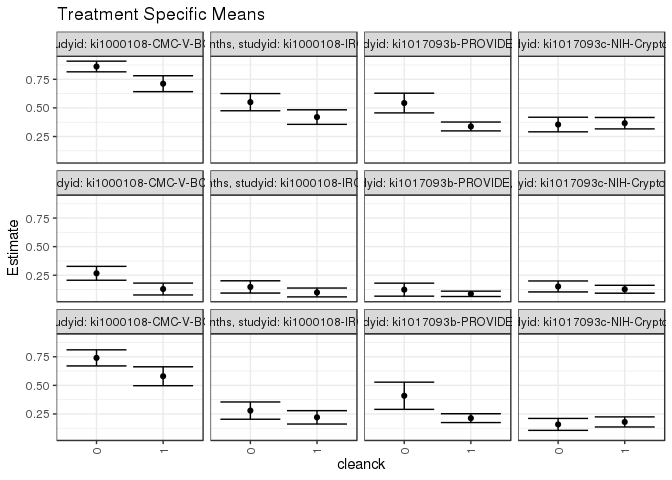

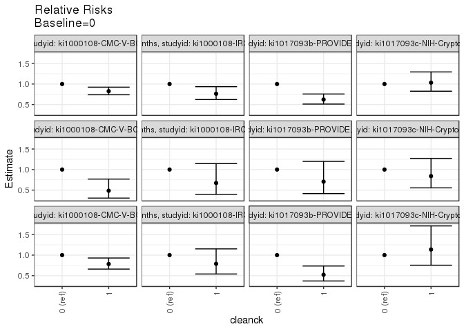

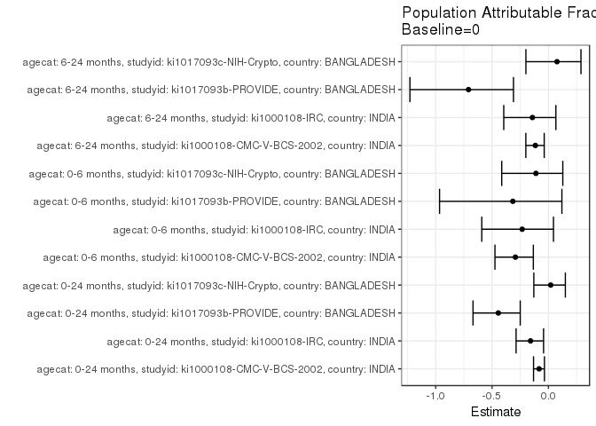

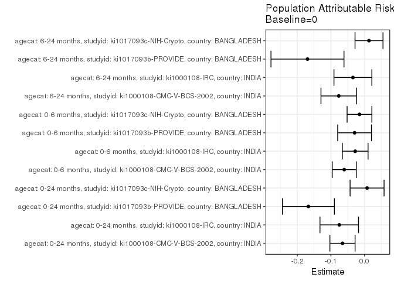

## Results Table

### Parameter: TSM

| agecat | studyid | country | intervention_level | baseline_level | estimate | ci_lower | ci_upper |
| --- | --- | --- | --- | --- | --- | --- | --- |
| 0-24 months | ki1000108-CMC-V-BCS-2002 | INDIA | 0 | NA | 0.8619048 | 0.8151807 | 0.9086288 |
| 0-24 months | ki1000108-CMC-V-BCS-2002 | INDIA | 1 | NA | 0.7116564 | 0.6420214 | 0.7812914 |
| 0-24 months | ki1000108-IRC | INDIA | 0 | NA | 0.5502959 | 0.4752011 | 0.6253907 |
| 0-24 months | ki1000108-IRC | INDIA | 1 | NA | 0.4199134 | 0.3561881 | 0.4836387 |
| 0-24 months | ki1017093b-PROVIDE | BANGLADESH | 0 | NA | 0.5426357 | 0.4566058 | 0.6286655 |
| 0-24 months | ki1017093b-PROVIDE | BANGLADESH | 1 | NA | 0.3380035 | 0.2991769 | 0.3768301 |
| 0-24 months | ki1017093c-NIH-Crypto | BANGLADESH | 0 | NA | 0.3548387 | 0.2911233 | 0.4185541 |
| 0-24 months | ki1017093c-NIH-Crypto | BANGLADESH | 1 | NA | 0.3666667 | 0.3168442 | 0.4164892 |
| 0-6 months | ki1000108-CMC-V-BCS-2002 | INDIA | 0 | NA | 0.2669903 | 0.2064969 | 0.3274837 |
| 0-6 months | ki1000108-CMC-V-BCS-2002 | INDIA | 1 | NA | 0.1296296 | 0.0778349 | 0.1814244 |
| 0-6 months | ki1000108-IRC | INDIA | 0 | NA | 0.1479290 | 0.0943354 | 0.2015226 |
| 0-6 months | ki1000108-IRC | INDIA | 1 | NA | 0.0995671 | 0.0609064 | 0.1382278 |
| 0-6 months | ki1017093b-PROVIDE | BANGLADESH | 0 | NA | 0.1240310 | 0.0671099 | 0.1809521 |
| 0-6 months | ki1017093b-PROVIDE | BANGLADESH | 1 | NA | 0.0875657 | 0.0643646 | 0.1107668 |
| 0-6 months | ki1017093c-NIH-Crypto | BANGLADESH | 0 | NA | 0.1520737 | 0.1042547 | 0.1998928 |
| 0-6 months | ki1017093c-NIH-Crypto | BANGLADESH | 1 | NA | 0.1277778 | 0.0932622 | 0.1622933 |
| 6-24 months | ki1000108-CMC-V-BCS-2002 | INDIA | 0 | NA | 0.7400000 | 0.6696830 | 0.8103170 |
| 6-24 months | ki1000108-CMC-V-BCS-2002 | INDIA | 1 | NA | 0.5797101 | 0.4972121 | 0.6622082 |
| 6-24 months | ki1000108-IRC | INDIA | 0 | NA | 0.2794118 | 0.2038849 | 0.3549387 |
| 6-24 months | ki1000108-IRC | INDIA | 1 | NA | 0.2205128 | 0.1622342 | 0.2787914 |
| 6-24 months | ki1017093b-PROVIDE | BANGLADESH | 0 | NA | 0.4090909 | 0.2903545 | 0.5278273 |
| 6-24 months | ki1017093b-PROVIDE | BANGLADESH | 1 | NA | 0.2134571 | 0.1747346 | 0.2521796 |
| 6-24 months | ki1017093c-NIH-Crypto | BANGLADESH | 0 | NA | 0.1587302 | 0.1065789 | 0.2108814 |
| 6-24 months | ki1017093c-NIH-Crypto | BANGLADESH | 1 | NA | 0.1802721 | 0.1362852 | 0.2242590 |

### Parameter: E(Y)

| agecat | studyid | country | intervention_level | baseline_level | estimate | ci_lower | ci_upper |
| --- | --- | --- | --- | --- | --- | --- | --- |
| 0-24 months | ki1000108-CMC-V-BCS-2002 | INDIA | NA | NA | 0.7962466 | 0.7553156 | 0.8371777 |
| 0-24 months | ki1000108-IRC | INDIA | NA | NA | 0.4750000 | 0.4260009 | 0.5239991 |
| 0-24 months | ki1017093b-PROVIDE | BANGLADESH | NA | NA | 0.3757143 | 0.3398113 | 0.4116172 |
| 0-24 months | ki1017093c-NIH-Crypto | BANGLADESH | NA | NA | 0.3622184 | 0.3229667 | 0.4014700 |
| 0-6 months | ki1000108-CMC-V-BCS-2002 | INDIA | NA | NA | 0.2065217 | 0.1651060 | 0.2479375 |
| 0-6 months | ki1000108-IRC | INDIA | NA | NA | 0.1200000 | 0.0881145 | 0.1518855 |
| 0-6 months | ki1017093b-PROVIDE | BANGLADESH | NA | NA | 0.0942857 | 0.0726222 | 0.1159492 |
| 0-6 months | ki1017093c-NIH-Crypto | BANGLADESH | NA | NA | 0.1369151 | 0.1088421 | 0.1649881 |
| 6-24 months | ki1000108-CMC-V-BCS-2002 | INDIA | NA | NA | 0.6631944 | 0.6085159 | 0.7178730 |
| 6-24 months | ki1000108-IRC | INDIA | NA | NA | 0.2447130 | 0.1983282 | 0.2910978 |
| 6-24 months | ki1017093b-PROVIDE | BANGLADESH | NA | NA | 0.2394366 | 0.2018814 | 0.2769918 |
| 6-24 months | ki1017093c-NIH-Crypto | BANGLADESH | NA | NA | 0.1718427 | 0.1381646 | 0.2055207 |

### Parameter: RR

| agecat | studyid | country | intervention_level | baseline_level | estimate | ci_lower | ci_upper |
| --- | --- | --- | --- | --- | --- | --- | --- |
| 0-24 months | ki1000108-CMC-V-BCS-2002 | INDIA | 0 | 0 | 1.0000000 | 1.0000000 | 1.0000000 |
| 0-24 months | ki1000108-CMC-V-BCS-2002 | INDIA | 1 | 0 | 0.8256787 | 0.7382949 | 0.9234053 |
| 0-24 months | ki1000108-IRC | INDIA | 0 | 0 | 1.0000000 | 1.0000000 | 1.0000000 |
| 0-24 months | ki1000108-IRC | INDIA | 1 | 0 | 0.7630685 | 0.6221978 | 0.9358334 |
| 0-24 months | ki1017093b-PROVIDE | BANGLADESH | 0 | 0 | 1.0000000 | 1.0000000 | 1.0000000 |
| 0-24 months | ki1017093b-PROVIDE | BANGLADESH | 1 | 0 | 0.6228922 | 0.5121370 | 0.7575994 |
| 0-24 months | ki1017093c-NIH-Crypto | BANGLADESH | 0 | 0 | 1.0000000 | 1.0000000 | 1.0000000 |
| 0-24 months | ki1017093c-NIH-Crypto | BANGLADESH | 1 | 0 | 1.0333333 | 0.8249857 | 1.2942986 |
| 0-6 months | ki1000108-CMC-V-BCS-2002 | INDIA | 0 | 0 | 1.0000000 | 1.0000000 | 1.0000000 |
| 0-6 months | ki1000108-CMC-V-BCS-2002 | INDIA | 1 | 0 | 0.4855219 | 0.3067074 | 0.7685875 |
| 0-6 months | ki1000108-IRC | INDIA | 0 | 0 | 1.0000000 | 1.0000000 | 1.0000000 |
| 0-6 months | ki1000108-IRC | INDIA | 1 | 0 | 0.6730736 | 0.3957553 | 1.1447175 |
| 0-6 months | ki1017093b-PROVIDE | BANGLADESH | 0 | 0 | 1.0000000 | 1.0000000 | 1.0000000 |
| 0-6 months | ki1017093b-PROVIDE | BANGLADESH | 1 | 0 | 0.7059982 | 0.4155873 | 1.1993472 |
| 0-6 months | ki1017093c-NIH-Crypto | BANGLADESH | 0 | 0 | 1.0000000 | 1.0000000 | 1.0000000 |
| 0-6 months | ki1017093c-NIH-Crypto | BANGLADESH | 1 | 0 | 0.8402357 | 0.5550975 | 1.2718415 |
| 6-24 months | ki1000108-CMC-V-BCS-2002 | INDIA | 0 | 0 | 1.0000000 | 1.0000000 | 1.0000000 |
| 6-24 months | ki1000108-CMC-V-BCS-2002 | INDIA | 1 | 0 | 0.7833921 | 0.6601821 | 0.9295969 |
| 6-24 months | ki1000108-IRC | INDIA | 0 | 0 | 1.0000000 | 1.0000000 | 1.0000000 |
| 6-24 months | ki1000108-IRC | INDIA | 1 | 0 | 0.7892038 | 0.5407656 | 1.1517793 |
| 6-24 months | ki1017093b-PROVIDE | BANGLADESH | 0 | 0 | 1.0000000 | 1.0000000 | 1.0000000 |
| 6-24 months | ki1017093b-PROVIDE | BANGLADESH | 1 | 0 | 0.5217840 | 0.3705475 | 0.7347466 |
| 6-24 months | ki1017093c-NIH-Crypto | BANGLADESH | 0 | 0 | 1.0000000 | 1.0000000 | 1.0000000 |
| 6-24 months | ki1017093c-NIH-Crypto | BANGLADESH | 1 | 0 | 1.1357143 | 0.7542837 | 1.7100290 |

### Parameter: PAR

| agecat | studyid | country | intervention_level | baseline_level | estimate | ci_lower | ci_upper |
| --- | --- | --- | --- | --- | --- | --- | --- |
| 0-24 months | ki1000108-CMC-V-BCS-2002 | INDIA | 0 | NA | -0.0656581 | -0.1030782 | -0.0282380 |
| 0-24 months | ki1000108-IRC | INDIA | 0 | NA | -0.0752959 | -0.1325234 | -0.0180683 |
| 0-24 months | ki1017093b-PROVIDE | BANGLADESH | 0 | NA | -0.1669214 | -0.2441373 | -0.0897054 |
| 0-24 months | ki1017093c-NIH-Crypto | BANGLADESH | 0 | NA | 0.0073797 | -0.0430863 | 0.0578456 |
| 0-6 months | ki1000108-CMC-V-BCS-2002 | INDIA | 0 | NA | -0.0604686 | -0.0962138 | -0.0247233 |
| 0-6 months | ki1000108-IRC | INDIA | 0 | NA | -0.0279290 | -0.0661637 | 0.0103057 |
| 0-6 months | ki1017093b-PROVIDE | BANGLADESH | 0 | NA | -0.0297453 | -0.0798965 | 0.0204059 |
| 0-6 months | ki1017093c-NIH-Crypto | BANGLADESH | 0 | NA | -0.0151587 | -0.0519664 | 0.0216490 |
| 6-24 months | ki1000108-CMC-V-BCS-2002 | INDIA | 0 | NA | -0.0768056 | -0.1295666 | -0.0240445 |
| 6-24 months | ki1000108-IRC | INDIA | 0 | NA | -0.0346988 | -0.0909867 | 0.0215891 |
| 6-24 months | ki1017093b-PROVIDE | BANGLADESH | 0 | NA | -0.1696543 | -0.2781176 | -0.0611910 |
| 6-24 months | ki1017093c-NIH-Crypto | BANGLADESH | 0 | NA | 0.0131125 | -0.0284262 | 0.0546511 |

### Parameter: PAF

| agecat | studyid | country | intervention_level | baseline_level | estimate | ci_lower | ci_upper |
| --- | --- | --- | --- | --- | --- | --- | --- |
| 0-24 months | ki1000108-CMC-V-BCS-2002 | INDIA | 0 | NA | -0.0824595 | -0.1319586 | -0.0351249 |
| 0-24 months | ki1000108-IRC | INDIA | 0 | NA | -0.1585176 | -0.2868280 | -0.0430011 |
| 0-24 months | ki1017093b-PROVIDE | BANGLADESH | 0 | NA | -0.4442774 | -0.6688449 | -0.2499288 |
| 0-24 months | ki1017093c-NIH-Crypto | BANGLADESH | 0 | NA | 0.0203735 | -0.1293478 | 0.1502458 |
| 0-6 months | ki1000108-CMC-V-BCS-2002 | INDIA | 0 | NA | -0.2927951 | -0.4742436 | -0.1336791 |
| 0-6 months | ki1000108-IRC | INDIA | 0 | NA | -0.2327416 | -0.5911464 | 0.0449327 |
| 0-6 months | ki1017093b-PROVIDE | BANGLADESH | 0 | NA | -0.3154804 | -0.9656251 | 0.1196243 |
| 0-6 months | ki1017093c-NIH-Crypto | BANGLADESH | 0 | NA | -0.1107157 | -0.4140864 | 0.1275713 |
| 6-24 months | ki1000108-CMC-V-BCS-2002 | INDIA | 0 | NA | -0.1158115 | -0.2003376 | -0.0372376 |
| 6-24 months | ki1000108-IRC | INDIA | 0 | NA | -0.1417938 | -0.3961158 | 0.0662000 |
| 6-24 months | ki1017093b-PROVIDE | BANGLADESH | 0 | NA | -0.7085561 | -1.2286255 | -0.3098496 |
| 6-24 months | ki1017093c-NIH-Crypto | BANGLADESH | 0 | NA | 0.0763052 | -0.1996272 | 0.2887690 |